# Gene Expression Analysis

# Run all documents

```r
library(quarto)
```

## Render individual documents

```r
quarto_render(input = "01_load.qmd")
file.rename(from = "01_load.html",
            to = "../results/01_load.html")
```

```r
quarto_render(input = "02_clean.qmd")
file.rename(from = "02_clean.html",
            to = "../results/02_clean.html")
```

```r
quarto_render(input = "03_describe.qmd")
file.rename(from = "03_describe.html",
            to = "../results/03_describe.html")
```

```r
quarto_render(input = "04_augment.qmd")
file.rename(from = "04_augment.html",
            to = "../results/04_augment.html")
```

```r
quarto_render(input = "05_analysis_1.qmd")
file.rename(from = "05_analysis_1.html",
            to = "../results/05_analysis_1.html")
```

```r
quarto_render(input = "06_analysis_2.qmd")
file.rename(from = "06_analysis_2.html",
            to = "../results/06_analysis_2.html")
```

## Run full analysis to create one html file

## Data Origin

The gene expression data used in this project is available in the Gene Expression Omnibus (GEO) under the accession number GSE50834. The data originates from the following paper:

Dawany N, Showe LC, Kossenkov AV, Chang C et al. Identification of a 251 gene expression signature that can accurately detect M. tuberculosis in patients with and without HIV co-infection. PLoS One 2014;9(2):e89925. PMID: 24587128

## Summary

The data comes from total RNA isolated from peripheral blood mononuclear cell (PBMC) from a South African cohort. Microarry analysis was performed to compare gene expression in patients either infected with HIV or co-infected with HIV and tuberculosis (TB). Diagnosis of TB, especially in the presence of an HIV co-infection, can be challenging when using conventional diagnostic methods. Therefore, the data was used to identify a TB-specific gene signature.

## Setup

Loading required packages.

```r
library("tidyverse")
library("stringr")
library("GEOquery")
```

Note: Instruction of how to install the package GEOquery can be found here *https://bioconductor.org/packages/release/bioc/html/GEOquery.html*

## Load Data

This document will load the data from Gene Expression Omnibus. Furthermore, the file will export the data as a tsv-file. In the following, the data directory is defined along with the location of the original data.

```r
dest_dir <- "../data/"
raw_dir <- str_c(dest_dir, "_raw/")
expr_file <- "GSE50834_non-normalized.txt.gz"
meta_file <- "GSE50834_series_matrix.txt.gz"
geo <- "GSE50834"

if( !dir.exists(raw_dir) ){
  dir.create(path = raw_dir,
             recursive = TRUE)
}
```

The gene expression data, containing patient ID’s and gene expression, is downloaded and stored in the raw data directory using the GEOquery library. GEOquery can download data sets from the NCBI Gene Expression Omnibus (GEO), using a unique accession number.

```r
if( !file.exists(str_c(raw_dir, expr_file)) ){
  getGEOSuppFiles(GEO = geo,
                  makeDirectory = FALSE,
                  baseDir = raw_dir,
                  fetch_files = TRUE,
                  filter_regex = "txt")
}

dat_expr <- read.table(file = str_c(raw_dir, expr_file),
                         sep = "\t",
                         header = TRUE)
```

The meta data, containing patient information, is downloaded and stored in the raw data directory.

```r
if (!file.exists(str_c(raw_dir, meta_file))){
  dat_meta <- getGEO(GEO = geo)
  dat_meta <- pData(phenoData(dat_meta[[1]]))
  write.table(dat_meta, file = str_c(raw_dir, meta_file),
             sep = "\t")
  dat_meta <- read.table(str_c(raw_dir, meta_file),
                        sep = "\t",
                        header = TRUE)
} else {
  dat_meta <- read.table(str_c(raw_dir, meta_file),
                          sep = "\t",
                          header = TRUE)
}
```

## Write Data to Files

The gene expression data and the meta data are saved as .tsv-files

```r
dat_expr |>
  write_tsv(file = str_c(dest_dir, "01_dat_load_expr.tsv"))

dat_meta |>
  write_tsv(file = str_c(dest_dir, "01_dat_load_meta.tsv"))
```

# Tidy data

## Setup

Load required packages.

```r
library("tidyverse")
```

Load gene expression and meta data.

```r
dat_expr <- read_tsv("../data/01_dat_load_expr.tsv")
dat_meta <- read_tsv("../data/01_dat_load_meta.tsv")
```

## Data Wrangling I

In this section, variable of gene expression data and meta data are variables are cleaned separately.

### Gene Expression Data

In the following the gene expression data is inspected, cleaned and simplified.

```r
dat_expr |>
  sample_n(10)
```

```
# A tibble: 10 × 89
   ID_REF       AAA0VKQN.12_18.Mar.2009 Detection.Pval AAA0W22R.11_16.Apr.2009
   <chr>                          <dbl>          <dbl>                   <dbl>
 1 ILMN_1659976                   1033.         0                        454.
 2 ILMN_1656672                    345.         0.0364                   151.
 3 ILMN_1786834                   1425.         0                        780.
 4 ILMN_1808508                    317.         0.109                    192.
 5 ILMN_1814204                  43201.         0                      21199.
 6 ILMN_3211537                    254.         0.555                    105.
 7 ILMN_2255130                    201.         0.719                    109.
 8 ILMN_1788756                    207.         0.708                     91.7
 9 ILMN_3309463                    251.         0.569                    133.
10 ILMN_3257864                    268.         0.455                    136.
# ℹ 85 more variables: Detection.Pval.1 <dbl>, AAA0W22R.14_16.Apr.2009 <dbl>,
#   Detection.Pval.2 <dbl>, BAA0V9SR.15_25.Feb.2009 <dbl>,
#   Detection.Pval.3 <dbl>, BAA0W3BM.11_20.Apr.2009 <dbl>,
#   Detection.Pval.4 <dbl>, BAA0W69B.10_29.Apr.2009 <dbl>,
#   Detection.Pval.5 <dbl>, BAA0WVPG.10_04.Jun.2009 <dbl>,
#   Detection.Pval.6 <dbl>, CAA0Q3CK.13_24.Apr.2008 <dbl>,
#   Detection.Pval.7 <dbl>, CAA0W4LJ.15_23.Apr.2009 <dbl>, …
```

From the inspection, it is seen that the data contain both gene expressions and p values. The detected p values are removed such that the gene expression data only consists of the gene expressions.

```r
dat_expr <- dat_expr |>
  dplyr::select(!matches(match = "Detection.Pval"))

dat_expr |>
  sample_n(10)
```

```
# A tibble: 10 × 45
   ID_REF   AAA0VKQN.12_18.Mar.2…¹ AAA0W22R.11_16.Apr.2…² AAA0W22R.14_16.Apr.2…³
   <chr>                     <dbl>                  <dbl>                  <dbl>
 1 ILMN_17…                   508.                  187.                    311.
 2 ILMN_17…                   500.                  196.                    420.
 3 ILMN_17…                   568.                  266.                    578.
 4 ILMN_17…                   675.                  276.                    524.
 5 ILMN_17…                   245.                  134.                    248.
 6 ILMN_17…                   298.                  136.                    236.
 7 ILMN_18…                   280.                  140.                    273.
 8 ILMN_17…                   146.                   79.0                   123.
 9 ILMN_32…                   822.                  387.                    522.
10 ILMN_33…                   260.                  104.                    221.
# ℹ abbreviated names: ¹AAA0VKQN.12_18.Mar.2009, ²AAA0W22R.11_16.Apr.2009,
#   ³AAA0W22R.14_16.Apr.2009
# ℹ 41 more variables: BAA0V9SR.15_25.Feb.2009 <dbl>,
#   BAA0W3BM.11_20.Apr.2009 <dbl>, BAA0W69B.10_29.Apr.2009 <dbl>,
#   BAA0WVPG.10_04.Jun.2009 <dbl>, CAA0Q3CK.13_24.Apr.2008 <dbl>,
#   CAA0W4LJ.15_23.Apr.2009 <dbl>, CAA0W4LT.13_23.Apr.2009 <dbl>,
#   DAA0PFCT.11_17.Jan.2008 <dbl>, DAA0V9RP.16_25.Feb.2009 <dbl>, …
```

Column names are simplified as the date is saved in the meta data.

```r
dat_expr |>
  colnames() = str_extract(string = colnames(dat_expr),
                           pattern = "^[A-Z0-9]+\\.?[0-9]*")

dat_expr |>
  sample_n(10)
```

```
# A tibble: 10 × 45
   ID    AAA0VKQN.12 AAA0W22R.11 AAA0W22R.14 BAA0V9SR.15 BAA0W3BM.11 BAA0W69B.10
   <chr>       <dbl>       <dbl>       <dbl>       <dbl>       <dbl>       <dbl>
 1 ILMN…        267.       122.         260.        255.        282.        142.
 2 ILMN…      62854.     33832.       60516.      60333.      64400.      33941.
 3 ILMN…       1040.       392.         661.       1271.        829.        601.
 4 ILMN…        214.       122.         176.        219.        226.        117.
 5 ILMN…        303.       123.         231.        315.        323.        176.
 6 ILMN…       1080.       386.         656.       1165.        875.        440.
 7 ILMN…        192.        98.3        188.        233.        220.        113.
 8 ILMN…       3652.      1818.        2936.       5105.       4990.       1982.
 9 ILMN…        336.       129.         271.        312.        303.        151.
10 ILMN…       1679.       759.        1485.       2347.       2005.        855.
# ℹ 38 more variables: BAA0WVPG.10 <dbl>, CAA0Q3CK.13 <dbl>, CAA0W4LJ.15 <dbl>,
#   CAA0W4LT.13 <dbl>, DAA0PFCT.11 <dbl>, DAA0V9RP.16 <dbl>, DAA0VD27.11 <dbl>,
#   FAA0W22D.13 <dbl>, HAA0W3B8.14 <dbl>, HAA0W3R9.13 <dbl>, JAA0P0DQ.11 <dbl>,
#   JAA0W223.10 <dbl>, KAA0PBTZ.17 <dbl>, KAA0Q3QH.14 <dbl>, AAA0WVKX.11 <dbl>,
#   EAA0VKQY.17 <dbl>, JAA0WVMP.13 <dbl>, AAA0KHPN.10 <dbl>, AAA0RWJ0.14 <dbl>,
#   AAA0Z4D1.15 <dbl>, AAA0ZSJX.10 <dbl>, BAA0YXVB.12 <dbl>, BAA0ZC4J.13 <dbl>,
#   BAA0ZXTF.11 <dbl>, CAA0ZN6L.12 <dbl>, DAA0Z4CR.10 <dbl>, …
```

### Meta Data

In the following the meta data is inspected, relevant columns are extracted, renamed and simplified

```r
colnames(dat_meta)
```

```
 [1] "title"                   "geo_accession"
 [3] "status"                  "submission_date"
 [5] "last_update_date"        "type"
 [7] "channel_count"           "source_name_ch1"
 [9] "organism_ch1"            "characteristics_ch1"
[11] "characteristics_ch1.1"   "characteristics_ch1.2"
[13] "molecule_ch1"            "extract_protocol_ch1"
[15] "label_ch1"               "label_protocol_ch1"
[17] "taxid_ch1"               "hyb_protocol"
[19] "scan_protocol"           "description"
[21] "description.1"           "data_processing"
[23] "platform_id"             "contact_name"
[25] "contact_email"           "contact_phone"
[27] "contact_laboratory"      "contact_institute"
[29] "contact_address"         "contact_city"
[31] "contact_state"           "contact_zip.postal_code"
[33] "contact_country"         "supplementary_file"
[35] "data_row_count"          "disease.state.ch1"
[37] "gender.ch1"              "sample.type.ch1"
```

We are interested in keeping ‘title’, ‘geo_accession’, and ‘description.1’. The last mentioned column is the identifier refering to each sample found in the gene expression data. Furthermore, we want to extract information about gender and disease state described by ‘characteristics_ch1’ and ‘characteristics_ch1.2’. This information is also found in the variables ‘gender.ch1’ and ‘disease.state.ch1’ in a nicer format. We chose to work with the first mentioned columns for educational purposes.

```r
dat_meta <- dat_meta |>
  dplyr::select(title,
                geo_accession,
                characteristics_ch1,
                characteristics_ch1.2,
                description.1) |>
  dplyr::rename("patient_n" = title,
                "gender" = characteristics_ch1,
                "disease_state" = characteristics_ch1.2,
                "identifier" = description.1)

dat_meta |>
  dplyr::select(patient_n,
         gender,
         disease_state,
         identifier) |>
  sample_n(10)
```

```
# A tibble: 10 × 4
   patient_n                     gender         disease_state         identifier
   <chr>                         <chr>          <chr>                 <chr>
 1 HIV infected patient 1        gender: Female disease state: HIV o… AAA0VKQN-…
 2 HIV/TB co-infected patient 19 gender: Male   disease state: HIV/TB KAA0ZMKX-…
 3 HIV infected patient 4        gender: Female disease state: HIV o… BAA0W3BM-…
 4 HIV infected patient 2_1      gender: Female disease state: HIV o… AAA0W22R-…
 5 HIV/TB co-infected patient 10 gender: Male   disease state: HIV/TB FAA0Z9CZ-…
 6 HIV infected patient 17       gender: Male   disease state: HIV o… JAA0W223-…
 7 HIV/TB co-infected patient 21 gender: Male   disease state: HIV/TB EAA0ZNH3-…
 8 HIV infected patient 21       gender: Male   disease state: HIV o… EAA0VKQY-…
 9 HIV/TB co-infected patient 20 gender: Male   disease state: HIV/TB KAA0ZQ5C-…
10 HIV/TB co-infected patient 18 gender: Female disease state: HIV/TB KAA0Z0GV-…
```

Simplify the columns ‘patient’, ‘gender’ and ‘disease state’.

```r
dat_meta <- dat_meta |>
  mutate(patient_n = str_extract(string = patient_n,
                                 pattern = "[0-9]+_?[0-9]?"),
         gender = str_extract(string = gender,
                              pattern = "Female|Male"),
         disease_state = str_extract(string = disease_state,
                              pattern = "HIV/TB|HIV"))
dat_meta |>
  sample_n(10)
```

```
# A tibble: 10 × 5
   patient_n geo_accession gender disease_state identifier
   <chr>     <chr>         <chr>  <chr>         <chr>
 1 9         GSM1230911    Female HIV           CAA0W4LT-13_23-Apr-2009
 2 20        GSM1230922    Female HIV           AAA0WVKX-11_04-Jun-2009
 3 8         GSM1230932    Male   HIV/TB        CAA0ZN6L-12_13-Jan-2010
 4 15        GSM1230939    Female HIV/TB        JAA0Q3QZ-15_24-Apr-2008
 5 15        GSM1230917    Female HIV           HAA0W3R9-13_21-Apr-2009
 6 7         GSM1230909    Female HIV           CAA0Q3CK-13_24-Apr-2008
 7 16        GSM1230918    Female HIV           JAA0P0DQ-11_15-Feb-2008
 8 1         GSM1230902    Female HIV           AAA0VKQN-12_18-Mar-2009
 9 17        GSM1230941    Female HIV/TB        JAA1063Y-11_03-Mar-2010
10 11        GSM1230913    Female HIV           DAA0V9RP-16_25-Feb-2009
```

The column ‘identifier’ in the meta data contain the names of the genes described in the expression data. In the following, the ‘identifier’ is corrected to mimic the genes of the expression data in order to join the two data sets later on.

The ‘identifier’ in the meta data is split into two columns to simplify the identifier but still keep the information about the dates.

```r
dat_meta <- dat_meta |>
  separate(col = identifier,
           into = c("identifier", "date"),
           sep = "_")

dat_meta |>
  sample_n(10)
```

```
# A tibble: 10 × 6
   patient_n geo_accession gender disease_state identifier  date
   <chr>     <chr>         <chr>  <chr>         <chr>       <chr>
 1 3         GSM1230905    Male   HIV           BAA0V9SR-15 25-Feb-2009
 2 13        GSM1230915    Male   HIV           FAA0W22D-13 16-Apr-2009
 3 21        GSM1230923    Male   HIV           EAA0VKQY-17 18-Mar-2009
 4 16        GSM1230940    Female HIV/TB        JAA103SD-11 25-Feb-2010
 5 1         GSM1230925    Female HIV/TB        AAA0KHPN-10 14-Jun-2007
 6 21        GSM1230945    Male   HIV/TB        EAA0ZNH3-13 13-Jan-2010
 7 2_1       GSM1230903    Female HIV           AAA0W22R-11 16-Apr-2009
 8 19        GSM1230943    Male   HIV/TB        KAA0ZMKX-10 11-Jan-2010
 9 2         GSM1230926    Female HIV/TB        AAA0RWJ0-14 02-Sep-2008
10 4         GSM1230928    Female HIV/TB        AAA0ZSJX-10 26-Jan-2010
```

```r
dat_meta <- dat_meta |>
  mutate(identifier = str_replace_all(string = identifier,
                                      pattern = "-",
                                      replacement = "."))
```

Check if there is consensus between the ‘identifiers’ in the meta data and the column names (gene names) of the gene expression data.

```r
meta_identifier <- dat_meta |>
  pull(identifier)

setdiff(colnames(dat_expr), meta_identifier)
```

```
[1] "ID"
```

The only difference between ‘identifier’ in meta data and column names of the gene expression data is the ‘ID’ column for the genes as expected.

## Data Wrangling II

In the following steps, the format of the data will be changed. Furthermore, we wish to join the gene expression data and the meta data.

### Data Pivoting

The gene expression data is transposed by pivoting sample ‘identifier’ to long format and gene ‘ID’ to wide format. The data should be tidy, which requires each observation, that is, each patient, must be a row, with the variables as columns.

```r
dat_expr <- dat_expr |>
  pivot_longer(cols = !ID,
               names_to = "identifier",
               values_to = "count") |>
  pivot_wider(names_from = ID,
              values_from = count)

dat_expr |>
  sample_n(10)
```

```
# A tibble: 10 × 47,232
   identifier  ILMN_1762337 ILMN_2055271 ILMN_1736007 ILMN_2383229 ILMN_1806310
   <chr>              <dbl>        <dbl>        <dbl>        <dbl>        <dbl>
 1 FAA0ZVHT.14         282.         316.         270.         262.         238.
 2 AAA0VKQN.12         334.         322.         323.         324.         245.
 3 KAA0PBTZ.17         216.         260.         218.         224.         180.
 4 HAA0Z4Z0.19         291.         315.         240.         300.         264.
 5 FAA0W22D.13         154.         169.         172.         133.         142.
 6 JAA103SD.11         126.         163.         132.         143.         123.
 7 AAA0W22R.11         158.         149.         149.         156.         142.
 8 CAA0W4LT.13         151.         144.         157.         128.         129.
 9 DAA0PFCT.11         287.         308.         275.         276.         244.
10 DAA0Z4CR.10         332.         264.         274.         341.         318.
# ℹ 47,226 more variables: ILMN_1779670 <dbl>, ILMN_1653355 <dbl>,
#   ILMN_1717783 <dbl>, ILMN_1705025 <dbl>, ILMN_1814316 <dbl>,
#   ILMN_2359168 <dbl>, ILMN_1731507 <dbl>, ILMN_1787689 <dbl>,
#   ILMN_3241953 <dbl>, ILMN_1745607 <dbl>, ILMN_2136495 <dbl>,
#   ILMN_1668111 <dbl>, ILMN_2295559 <dbl>, ILMN_1735045 <dbl>,
#   ILMN_1680754 <dbl>, ILMN_2375184 <dbl>, ILMN_1659452 <dbl>,
#   ILMN_1767388 <dbl>, ILMN_1675204 <dbl>, ILMN_1673870 <dbl>, …
```

### Data Joining

The meta data and the count data should be merge such that all data about a patient is contained in one tibble. Meta data should be in the first columns followed by gene variables.

```r
dat_clean <- inner_join(x = dat_expr,
                        y = dat_meta,
                        by = "identifier") |>
  relocate(colnames(dat_meta))

dat_clean |>
  sample_n(10)
```

```
# A tibble: 10 × 47,237
   patient_n geo_accession gender disease_state identifier  date    ILMN_1762337
   <chr>     <chr>         <chr>  <chr>         <chr>       <chr>          <dbl>
 1 6         GSM1230908    Female HIV           BAA0WVPG.10 04-Jun…         157.
 2 15        GSM1230939    Female HIV/TB        JAA0Q3QZ.15 24-Apr…         179.
 3 13        GSM1230915    Male   HIV           FAA0W22D.13 16-Apr…         154.
 4 2_1       GSM1230903    Female HIV           AAA0W22R.11 16-Apr…         158.
 5 6         GSM1230930    Male   HIV/TB        BAA0ZC4J.13 07-Dec…         206.
 6 19        GSM1230943    Male   HIV/TB        KAA0ZMKX.10 11-Jan…         338.
 7 15        GSM1230917    Female HIV           HAA0W3R9.13 21-Apr…         315.
 8 17        GSM1230941    Female HIV/TB        JAA1063Y.11 03-Mar…         122.
 9 1         GSM1230902    Female HIV           AAA0VKQN.12 18-Mar…         334.
10 11        GSM1230913    Female HIV           DAA0V9RP.16 25-Feb…         298.
# ℹ 47,230 more variables: ILMN_2055271 <dbl>, ILMN_1736007 <dbl>,
#   ILMN_2383229 <dbl>, ILMN_1806310 <dbl>, ILMN_1779670 <dbl>,
#   ILMN_1653355 <dbl>, ILMN_1717783 <dbl>, ILMN_1705025 <dbl>,
#   ILMN_1814316 <dbl>, ILMN_2359168 <dbl>, ILMN_1731507 <dbl>,
#   ILMN_1787689 <dbl>, ILMN_3241953 <dbl>, ILMN_1745607 <dbl>,
#   ILMN_2136495 <dbl>, ILMN_1668111 <dbl>, ILMN_2295559 <dbl>,
#   ILMN_1735045 <dbl>, ILMN_1680754 <dbl>, ILMN_2375184 <dbl>, …
```

### Handling Replicates

There are two technical replicates available for one patient, namely patient 2_1 and 2_2 indicated by the ‘patient_n’ column. We wish to averaged the measurements for this patient for further analysis.

First, the gene expression values for the replicates are extracted.

```r
dat_rep <- dat_clean |>
  filter(str_detect(patient_n, "_")) |>
  mutate(patient_n = str_extract(string = patient_n,
                                 pattern = "[0-9]+"))

dat_rep
```

```
# A tibble: 2 × 47,237
  patient_n geo_accession gender disease_state identifier  date     ILMN_1762337
  <chr>     <chr>         <chr>  <chr>         <chr>       <chr>           <dbl>
1 2         GSM1230903    Female HIV           AAA0W22R.11 16-Apr-…         158.
2 2         GSM1230904    Female HIV           AAA0W22R.14 16-Apr-…         300.
# ℹ 47,230 more variables: ILMN_2055271 <dbl>, ILMN_1736007 <dbl>,
#   ILMN_2383229 <dbl>, ILMN_1806310 <dbl>, ILMN_1779670 <dbl>,
#   ILMN_1653355 <dbl>, ILMN_1717783 <dbl>, ILMN_1705025 <dbl>,
#   ILMN_1814316 <dbl>, ILMN_2359168 <dbl>, ILMN_1731507 <dbl>,
#   ILMN_1787689 <dbl>, ILMN_3241953 <dbl>, ILMN_1745607 <dbl>,
#   ILMN_2136495 <dbl>, ILMN_1668111 <dbl>, ILMN_2295559 <dbl>,
#   ILMN_1735045 <dbl>, ILMN_1680754 <dbl>, ILMN_2375184 <dbl>, …
```

The mean gene expression is calculated for each replicated patient.

```r
dat_rep_mean <- dat_rep |>
  group_by(patient_n) |>
  summarise(across(.cols = starts_with("ILMN"),
                   .fns = mean,
                   na.rm = TRUE))
dat_rep_mean
```

```
# A tibble: 1 × 47,232
  patient_n ILMN_1762337 ILMN_2055271 ILMN_1736007 ILMN_2383229 ILMN_1806310
  <chr>            <dbl>        <dbl>        <dbl>        <dbl>        <dbl>
1 2                 229.         209.         200.         192.         189.
# ℹ 47,226 more variables: ILMN_1779670 <dbl>, ILMN_1653355 <dbl>,
#   ILMN_1717783 <dbl>, ILMN_1705025 <dbl>, ILMN_1814316 <dbl>,
#   ILMN_2359168 <dbl>, ILMN_1731507 <dbl>, ILMN_1787689 <dbl>,
#   ILMN_3241953 <dbl>, ILMN_1745607 <dbl>, ILMN_2136495 <dbl>,
#   ILMN_1668111 <dbl>, ILMN_2295559 <dbl>, ILMN_1735045 <dbl>,
#   ILMN_1680754 <dbl>, ILMN_2375184 <dbl>, ILMN_1659452 <dbl>,
#   ILMN_1767388 <dbl>, ILMN_1675204 <dbl>, ILMN_1673870 <dbl>, …
```

The metadata for each replicated patient is extracted. The ‘geo accession’ and ‘identifer’ is collapsed, meaning that the new ‘geo accession’ and ‘identifer’ for the replicated patient is a combination of the originals.

```r
cols_rep_meta_collapesed <- dat_rep |>
  group_by(patient_n) |>
  mutate(geo_accession = str_c(geo_accession, collapse = "_"),
            identifier = str_c(identifier, collapse = "_"))

cols_rep_meta_collapesed
```

```
# A tibble: 2 × 47,237
# Groups:   patient_n [1]
  patient_n geo_accession     gender disease_state identifier date  ILMN_1762337
  <chr>     <chr>             <chr>  <chr>         <chr>      <chr>        <dbl>
1 2         GSM1230903_GSM12… Female HIV           AAA0W22R.… 16-A…         158.
2 2         GSM1230903_GSM12… Female HIV           AAA0W22R.… 16-A…         300.
# ℹ 47,230 more variables: ILMN_2055271 <dbl>, ILMN_1736007 <dbl>,
#   ILMN_2383229 <dbl>, ILMN_1806310 <dbl>, ILMN_1779670 <dbl>,
#   ILMN_1653355 <dbl>, ILMN_1717783 <dbl>, ILMN_1705025 <dbl>,
#   ILMN_1814316 <dbl>, ILMN_2359168 <dbl>, ILMN_1731507 <dbl>,
#   ILMN_1787689 <dbl>, ILMN_3241953 <dbl>, ILMN_1745607 <dbl>,
#   ILMN_2136495 <dbl>, ILMN_1668111 <dbl>, ILMN_2295559 <dbl>,
#   ILMN_1735045 <dbl>, ILMN_1680754 <dbl>, ILMN_2375184 <dbl>, …
```

A new column called ‘modified’ is added to the meta data. The column describes if the patient has been modified (eg. the gene expression represent a mean of multiple gene expressions for one patient).

```r
cols_rep_meta <- cols_rep_meta_collapesed |>
  dplyr::select(!starts_with("ILMN")) |>
  distinct() |>
 mutate(modified = 1)

cols_rep_meta
```

```
# A tibble: 1 × 7
# Groups:   patient_n [1]
  patient_n geo_accession         gender disease_state identifier date  modified
  <chr>     <chr>                 <chr>  <chr>         <chr>      <chr>    <dbl>
1 2         GSM1230903_GSM1230904 Female HIV           AAA0W22R.… 16-A…        1
```

```r
dat_clean <- dat_clean |>
  mutate(modified = 0)
```

Combine the new meta data with the mean gene expression for the each replicated patient.

```r
dat_rep_clean <- inner_join(x = cols_rep_meta,
                            y = dat_rep_mean,
                            by = "patient_n")
```

Finally, the new data for th replicated patients are combines with the data for the non-replicated patients to form a clean data set without replicates.

As the patient_n variable is no longer informative, this column is removed for all patients.

```r
dat_clean <- full_join(dat_clean, dat_rep_clean) |>
  relocate(modified, .after = date) |>
  filter(!str_detect(patient_n, "_")) |>
  dplyr::select(!patient_n) |>
  arrange(disease_state)

dat_clean |>
  sample_n(10)
```

```
# A tibble: 10 × 47,237
   geo_accession gender disease_state identifier  date     modified ILMN_1762337
   <chr>         <chr>  <chr>         <chr>       <chr>       <dbl>        <dbl>
 1 GSM1230919    Male   HIV           JAA0W223.10 16-Apr-…        0         166.
 2 GSM1230928    Female HIV/TB        AAA0ZSJX.10 26-Jan-…        0         274.
 3 GSM1230933    Male   HIV/TB        DAA0Z4CR.10 25-Nov-…        0         332.
 4 GSM1230916    Female HIV           HAA0W3B8.14 20-Apr-…        0         141.
 5 GSM1230934    Male   HIV/TB        FAA0Z9CZ.10 03-Dec-…        0         300.
 6 GSM1230930    Male   HIV/TB        BAA0ZC4J.13 07-Dec-…        0         206.
 7 GSM1230911    Female HIV           CAA0W4LT.13 23-Apr-…        0         151.
 8 GSM1230924    Female HIV           JAA0WVMP.13 04-Jun-…        0         260.
 9 GSM1230939    Female HIV/TB        JAA0Q3QZ.15 24-Apr-…        0         179.
10 GSM1230913    Female HIV           DAA0V9RP.16 25-Feb-…        0         298.
# ℹ 47,230 more variables: ILMN_2055271 <dbl>, ILMN_1736007 <dbl>,
#   ILMN_2383229 <dbl>, ILMN_1806310 <dbl>, ILMN_1779670 <dbl>,
#   ILMN_1653355 <dbl>, ILMN_1717783 <dbl>, ILMN_1705025 <dbl>,
#   ILMN_1814316 <dbl>, ILMN_2359168 <dbl>, ILMN_1731507 <dbl>,
#   ILMN_1787689 <dbl>, ILMN_3241953 <dbl>, ILMN_1745607 <dbl>,
#   ILMN_2136495 <dbl>, ILMN_1668111 <dbl>, ILMN_2295559 <dbl>,
#   ILMN_1735045 <dbl>, ILMN_1680754 <dbl>, ILMN_2375184 <dbl>, …
```

## Write Data to File

The cleaned data is written as a tsv file.

```r
dat_clean |>
  write_tsv(file = "../data/02_dat_clean.tsv")
```

# Describe data

## Setup

Loading required packages

```r
library("tidyverse")
library("stringr")
library("table1")
```

Loading the cleaned data.

```r
dat_clean <- read_tsv("../data/02_dat_clean.tsv")
```

## Data Description

Define setting for bar plot to illustrate the number of males and females for each patient group.

```r
female_sign = intToUtf8(9792)
male_sign = intToUtf8(9794)
sign_size = 10
bar_width = 0.75

groups <- dat_clean |>
  group_by(gender,
           disease_state) |>
  summarize(n = n())
```

Create plot.

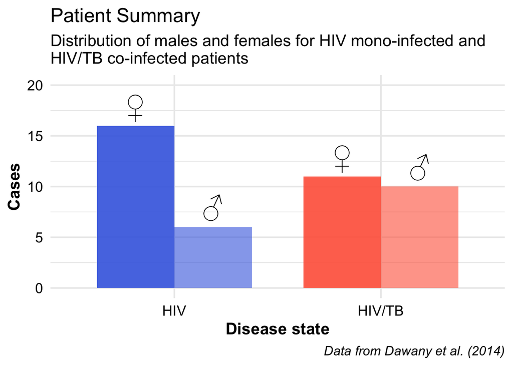

```r
barplot_patient_group <- ggplot(data = dat_clean,
                                mapping = aes(x = disease_state,
                                              fill = disease_state,
                                              alpha = gender)) +
  geom_bar(width = bar_width,
           position = "dodge") +
  scale_fill_manual(
    values = c("HIV" = "royalblue",
               "HIV/TB" = "tomato") ) +
  scale_alpha_manual(values = c("Male" = 0.6,
                                "Female" = 0.9)) +
  annotate("text",
           x = 1:2 - bar_width/4,
           y = groups$n[1:2] + 2,
           label = female_sign,
           size = sign_size) +
  annotate("text",
           x = 1:2 + bar_width/4,
           y = groups$n[3:4] + 2,
           label = male_sign,
           size = sign_size) +
  coord_cartesian(ylim =  c(0, 20)) +
  theme_minimal(base_size = 16) +
  labs(
    x = "Disease state",
    y = "Cases",
    fill = "Gender",
    title = "Patient Summary",
    subtitle = str_c("Distribution of males and females for HIV mono-infected and",
                     "\n",
                     "HIV/TB co-infected patients"),
    caption = "Data from Dawany et al. (2014)"
  ) +
  theme(legend.position = "none",
        axis.text.x = element_text(color = "black",
                                   size = 14),
        axis.text.y = element_text(color = "black",
                                   size = 14),
        axis.title = element_text(face="bold"),
        plot.caption = element_text(face = "italic"))

ggsave("../results/barplot_patient_group.png", plot = barplot_patient_group)
show(barplot_patient_group)
```

The distribution of males and females for each patient group can also be summarized in a table.

```r
summary_table <- dat_clean |>
  mutate(Gender = factor(gender),
         Disease = factor(disease_state)) |>
  table1(x = formula(~ Gender | Disease))
show(summary_table)
```

[output not shown]

From the above it is seen, that the gender of the HIV/TB co-infected patients is close to equal distributed between male and female, and that the gender of the HIV mono-infected is unequal distributed with 72% females and only 27% males.

# Augment data

## Setup

Loading required packages.

```r
library("tidyverse")
library("preprocessCore")
```

Load the clean data.

```r
dat_clean <- read_tsv(file = "../data/02_dat_clean.tsv")
```

In the following the gene expression data will be normalized and log2 transformed. In order to do so the clean data is split into gene expression data and meta data.

```r
dat_expr <- dat_clean |>
  dplyr::select(starts_with("ILMN"))

dat_meta <- dat_clean |>
  dplyr::select(!starts_with("ILMN"))
```

## Normalization

The purpose of normalization is to minimize technical variability such that the remaining variation can be explained by biological differences. Technical variation can occur because of preparation differences or differences in the production of the microarrays and the processing of the arrays (for instance scanner differences). A general strategy is to re-distribute signal intensities across all samples such that they now all have the same distribution in order to compare the data from multiple samples.

The gene expression levels in the cleaned data are normalized by quantile normalization implemented in the function “r normalize.quantiles()”. This ensures that expression levels can be compared between patients in the data set. The algorithm is as follows:

1. Sort the the expression levels for each patient.
2. Calculate the mean expression level of the genes within the same rank.
3. Assign this mean to each gene within this rank.
4. Rearranging the genes for each patient to obtain the original order.

```r
dat_expr_matrix <- as.matrix(t(dat_expr))

colnames(dat_expr_matrix) <- dat_meta |>
  pull(identifier)

dat_expr <- normalize.quantiles(x = dat_expr_matrix,
                                keep.names = TRUE) |>
  t() |>
  as_tibble(rownames = NA)
```

## Log Transformation

In the following, the gene expression data is log2 transformed. This method is commonly used for microarray data to handle the issue that higher expression levels tend to have higher variance and vice versa.

```r
dat_expr <- dat_expr |>
  rownames_to_column(var = "identifier") |>
  mutate(across(starts_with("ILMN"), log2))
```

The normalized and log2 transformed gene expression data and the meta-data are combined.

```r
dat_aug <- inner_join(x = dat_meta,
                      y = dat_expr,
                      by = "identifier")
```

## Write Data to Files

The data is saved as .tsv-files.

```r
dat_aug |>
  write_tsv(file = "../data/04_dat_aug.tsv")
```

This was just a way to briefly see the effect and is not expected to be included in the final code:

## Effect of Normalization

To better understand the normalization, the distribution of the expression level is examined before normalization.

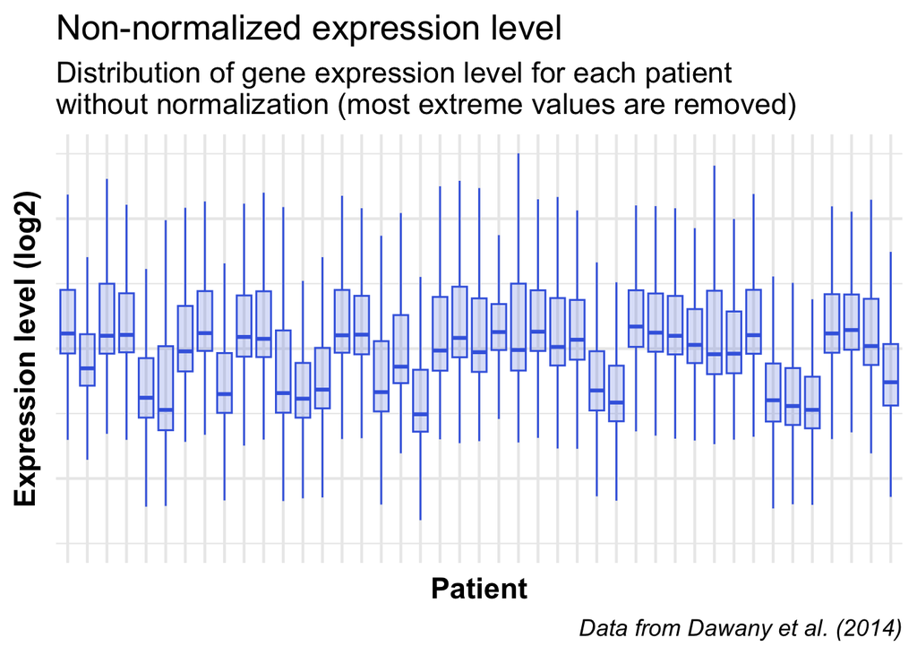

```r
non_normalized_expr <- dat_clean |>
  pivot_longer(cols = starts_with("ILMN"),
               names_to = "gene_id",
               values_to = "expression") |>
  mutate(log2_expression = log2(expression)) |>
  ggplot(mapping = aes(x = geo_accession,
                       y = log2_expression)) +
  geom_boxplot(outlier.shape = NA,
               color = "royalblue",
               fill = "royalblue",
               alpha = 0.2) +
  coord_cartesian(ylim =  c(5, 11)) +
  theme_minimal(base_size = 16) +
  labs(x = "Patient",
       y = "Expression level (log2)",
       title = "Non-normalized expression level",
       subtitle = str_c("Distribution of gene expression level for each patient",
                        "\n",
                        "without normalization (most extreme values are removed)"),
       caption = "Data from Dawany et al. (2014)") +
  theme(axis.text.x = element_blank(),
        axis.text.y = element_blank(),
        axis.title = element_text(face="bold"),
        plot.caption = element_text(face = "italic"),
        legend.text = element_text(size = 14))

ggsave("../results/non_normalized_expr.png", plot = non_normalized_expr)
show(non_normalized_expr)
```

After normalization, the quantiles for the expression level is equal for each patient.

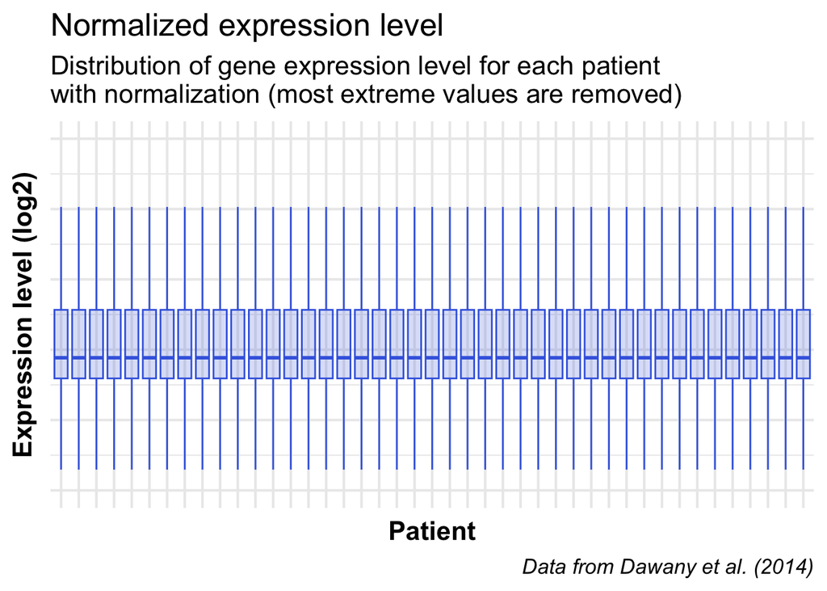

```r
normalized_expr <- dat_aug |>
  pivot_longer(cols = starts_with("ILMN"),
               names_to = "gene_id",
               values_to = "log2_norm_expression") |>
  ggplot(mapping = aes(x = geo_accession,
                       y = log2_norm_expression)) +
  geom_boxplot(outlier.shape = NA,
               color = "royalblue",
               fill = "royalblue",
               alpha = 0.2) +
  coord_cartesian(ylim =  c(6, 11)) +
  theme_minimal(base_size = 16) +
  labs(x = "Patient",
       y = "Expression level (log2)",
       title = "Normalized expression level",
       subtitle = str_c("Distribution of gene expression level for each patient",
                        "\n",
                        "with normalization (most extreme values are removed)"),
       caption = "Data from Dawany et al. (2014)") +
  theme(axis.text.x = element_blank(),
        axis.text.y = element_blank(),
        axis.title = element_text(face="bold"),
        plot.caption = element_text(face = "italic"),
        legend.text = element_text(size = 14))

ggsave("../results/normalized_expr.png", plot = normalized_expr)
show(normalized_expr)
```

# PCA analysis

## Setup

Loading required packages.

```r
library('tidyverse')
library("stringr")
library('broom')
```

Load the augment data.

```r
dat_aug <- read_tsv(file = "../data/04_dat_aug.tsv")
```

## Principal Component Analysis

In the following a Principal Component Analysis (PCA) is carried out on the augment data.

```r
pca_fit <- dat_aug |>
  select(starts_with("ILMN")) |>
  prcomp()

pca_fit_aug <- pca_fit |>
  augment(dat_aug)
```

### Plot Principal Components

The Principal Components (PC) of the PCA is plotted against each other.

First, the first PC is plotted against the second PC.

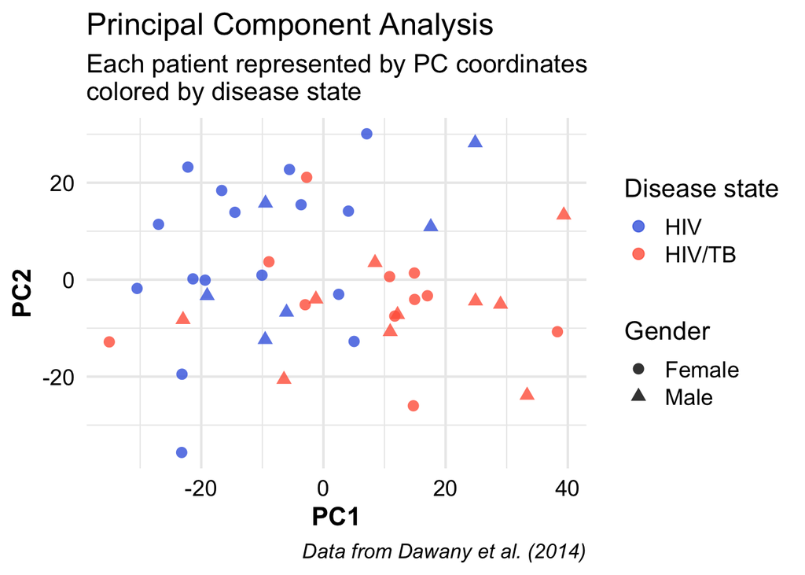

```r
scatter_pc1_pc2 <- ggplot(data = pca_fit_aug,
                          mapping = aes(x = .fittedPC1,
                                        y = .fittedPC2,
                                        color = disease_state,
                                        shape = gender)) +
  geom_point(size = 3,
             alpha = 0.8) +
  scale_color_manual(
    values = c("HIV" = "royalblue",
               "HIV/TB" = "tomato")) +
  theme_minimal(base_size = 16) +
  labs(x = "PC1",
       y = "PC2",
       color = "Disease state",
       shape = "Gender",
       title = "Principal Component Analysis",
       subtitle = str_c("Each patient represented by PC coordinates",
                        "\n",
                        "colored by disease state"),
       caption = "Data from Dawany et al. (2014)") +
  theme(axis.text.x = element_text(color = "black",
                                   size = 14),
        axis.text.y = element_text(color = "black",
                                   size = 14),
        axis.title = element_text(face="bold"),
        plot.caption = element_text(face = "italic"),
        legend.text = element_text(size = 14))

ggsave("../results/scatter_pc1_pc2.png", plot = scatter_pc1_pc2)
show(scatter_pc1_pc2)
```

From above it is seen, that PC1 to some extend is able to distinguis between HIV/TB co-infected and HIV mono-infected patients, while PC2 show no prominent pattern related to infection or gender.

### Plot the Variance Explained

The variance explained by each PC is plotted.

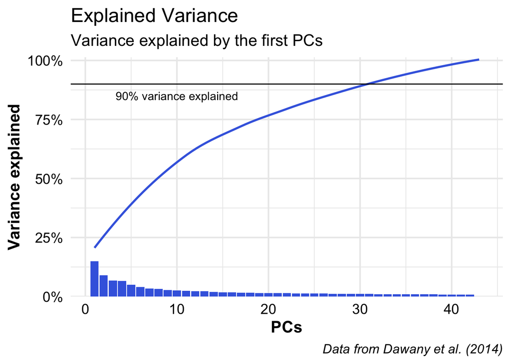

```r
pca_fit_eigen <- pca_fit |>
  tidy(matrix = "eigenvalues")

var_explained <- ggplot(data = pca_fit_eigen,
                        mapping = aes(x = PC,
                                      y = percent)) +
  geom_col(fill = "royalblue") +
  geom_smooth(mapping = aes(x = PC,
                            y = cumulative),
              method = "loess",
              formula = y ~ x,
              color = "royalblue",
              se = FALSE) +
  geom_hline(yintercept = 0.90) +
  annotate("text",
           x=10,
           y=0.85,
           label="90% variance explained",
           size = 4) +
  scale_y_continuous(
    labels = scales::percent_format(),
    expand = expansion(mult = c(0, 0.01))) +
  theme_minimal(base_size = 16) +
  labs(x = "PCs",
       y = "Variance explained",
       title = "Explained Variance",
       subtitle = "Variance explained by the first PCs",
       caption = "Data from Dawany et al. (2014)") +
  theme(axis.text.x = element_text(color = "black",
                                   size = 14),
        axis.text.y = element_text(color = "black",
                                   size = 14),
        axis.title = element_text(face="bold"),
        plot.caption = element_text(face = "italic"),
        legend.text = element_text(size = 14))

ggsave("../results/var_explained.png", plot = var_explained)
show(var_explained)
```

# Linear regression analysis

## Setup

Loading required packages.

```r
library('tidyverse')
library('broom')
library("ggrepel")
library("illuminaHumanv4.db")
```

Load the augment data.

```r
dat_aug <- read_tsv(file = "../data/04_dat_aug.tsv")
```

## Linear Regression

In the following a linear regression model is mapped to the data. In order to do so, the data need to be pivoted to long format and grouped by genes. Gene expression levels and disease label are nested pr. gene.

```r
dat_nest <- dat_aug |>
  mutate(disease_state = case_when(disease_state == "HIV" ~ 0,
                                   disease_state == "HIV/TB" ~ 1)) |>
  pivot_longer(cols = matches("^ILMN_[0-9]+"),
               names_to = "gene",
               values_to = "log2_expr_level") |>
               group_by(gene) |>
               nest()

dat_nest
```

```
# A tibble: 47,231 × 2
# Groups:   gene [47,231]
   gene         data
   <chr>        <list>
 1 ILMN_1762337 <tibble [43 × 7]>
 2 ILMN_2055271 <tibble [43 × 7]>
 3 ILMN_1736007 <tibble [43 × 7]>
 4 ILMN_2383229 <tibble [43 × 7]>
 5 ILMN_1806310 <tibble [43 × 7]>
 6 ILMN_1779670 <tibble [43 × 7]>
 7 ILMN_1653355 <tibble [43 × 7]>
 8 ILMN_1717783 <tibble [43 × 7]>
 9 ILMN_1705025 <tibble [43 × 7]>
10 ILMN_1814316 <tibble [43 × 7]>
# ℹ 47,221 more rows
```

A linear regression model is mapped to the nested data of each gene.

```r
dat_nest <- dat_nest |>
  mutate(model_object = map(.x = data,
                            .f = ~lm(formula = log2_expr_level ~ disease_state,
                                     data = .x)))
```

Tidy statistics are mapped to the model of each gene and saved in ‘tidy_model_object’.

```r
dat_nest <- dat_nest |>
  mutate(tidy_model_object = map(.x = model_object,
                                 .f = ~tidy(conf.int = TRUE,
                                            conf.level = 0.95,
                                            x = .x)))
```

The tidy model objects are unnested, only slope estimates are kept for each gene and selected together with p-values and CI values. Lastly, the data is being ungrouped.

```r
dat_estimates <- dat_nest |>
  unnest(tidy_model_object) |>
  filter(term != "(Intercept)") |>
  dplyr::select(gene,
         p.value,
         estimate,
         conf.low,
         conf.high) |>
  ungroup()
```

An adjusted p-value is calculated and added to the data estimate table together with a “significant label” based on a 0.05%.

```r
dat_estimates <- dat_estimates |>
  mutate(p_val_adjust = p.adjust(p.value),
         significant = case_when(p_val_adjust <= 0.05 ~ "Yes", TRUE ~"No"))

dat_estimates |>
  filter(significant == "Yes") |>
  summarise(n = n())
```

```
# A tibble: 1 × 1
      n
  <int>
1    40
```

We convert the illumina probe names to the gene symbol.

```r
dat_estimates <- dat_estimates |>
  mutate(gene_symbol = map(.x = gene,
                           .f = ~ get(x = .x,
                                      envir = illuminaHumanv4SYMBOL)),
         gene_symbol = unlist(gene_symbol))
```

### Compare most significant genes with list of diagnostic genes from the 251 gene signature from the paper (Dawany N.).

Extract the significant genes with original gene ID

```r
significant_genes <- dat_estimates |>
  filter(significant == "Yes") |>
  dplyr::select(gene_symbol) |>
  pull()
```

THe 251 signature genes for TB/HIV vs. HIV from the reference paper of the data (Dawany, N.) are copied from a docx file “List of the 251 gene TB-signature identified using SVM-RFE”: “pone.0089925.s007.docx” available from the paper. We are aware, that it would be better to extract the information directly from the file for reproducability, but due to issues accesing the docx file and limited time, this solution is used.

```r
signature_251_str <- c("DHRS4
EYA3
CMIP
UBTF
TMEM164
CDKN2B
PTK2
LOC648605
NaN
ACOX3
MLKL
ATP5I
STX6
WTAP
MR1
LOC151579
SIK3
USP41
WDR63
INTS3
LOC653717
TLN1
NINJ2
GRAMD3
SCAND2
RSPH3
CREB3L2
PARP2
NENF
TNFRSF14
CSNK1G3
AMY1B
TIAL1
MOBKL2C
LOC728635
LOC285053
C3orf64
USP34
NaN
RTN1
EIF3J
PPM1F
REL
C16orf48
ASCL2
STX6
ACVR1
ZNF91
MICB
MSRB2
TCEA1
BTBD1
DHRS4L2
LOC402057
HPCAL1
P2RY13
LOC388122
MATR3
KIAA0947
APOL6
GK
HLA-DMA
FDFT1
GBP2
ST3GAL2
GK
BCCIP
BRSK1
MLKL
MALT1
CPEB3
LOC648605
TXNIP
NaN
TMEM51
ETV6
SUMO4
MTDH
RAB11FIP1
DNAJC2
LOC399715
NCBP2
EPB41L4A
NaN
ZNF516
NaN
LOC648210
LOC285359
FLVCR2
RBBP7
HSPD1
UAP1
ZWILCH
NCL
TRAFD1
RNF181
PACSIN2
PDCD6
FLJ38973
WDR43
PIK3R1
WBP2
RPRC1
C1orf54
C6orf47
NaN
DNAL4
KIAA0319L
SUB1
C19orf56
TNPO1
G6PD
LOC91431
LOC648057
SNORD36A
CDKN2D
LMO4
ASCC3
C7orf36
MPZL2
NPTN
TGIF1
UBE2Q2
NaN
CLK1
KIAA0146
RNF19A
NEDD8
LOC390354
YME1L1
LPCAT2
NaN
PCDHA1
LZTFL1
SEPT5
CCDC99
LOC285176
KIAA1370
MRPL47
C9orf91
KIAA1333
FAM120A
LOC644380
MYL6
BZW1
ASPHD2
ABCE1
PCGF6
TSPYL2
NCOA4
SFXN1
IRF1
COASY
TAOK2
RAB24
AEBP2
PPP2CB
HLA-DMB
SFRS2IP
NaN
USP16
KPNA3
MAN1A1
SDHAP3
HIF1AN
SLC25A3
PCMT1
BZW1
ZNF124
ZNF679
S100Z
STAT2
WAS
DHRS4
TRIM23
NaN
MEFV
R3HDM1
DHRS9
LOC653610
DGAT1
DNAJB6
SFRS3
EED
NaN
ZNF254
ANKRD44
CDK6
ZNF451
NAE1
REV3L
ITGA4
UBA2
PGCP
GOLT1B
NARG2
PRCP
TIPIN
SNORA25
CASP4
PCF11
LOC649555
TPMT
RANBP2
TCP11L1
NCL
LOC654189
ZC3H15
G6PD
NAGK
SUMF1
CARM1
PPBP
FASTKD2
C10orf54
PDE4D
NaN
KRAS
ARSA
MRPL35
ARL4C
SMAD7
SNORA32
CCNC
UBE2L6
C2orf79
TMLHE
LOC90120
MALT1
IFNAR2
FLJ10996
LOC647436
TAF9
NPIP
YME1L1
EED
ZNF624
ANAPC1
ZNF669
STAT1
SNX27
MOBKL2A
HSP90AA1
ZNF644
KIAA0020
LOC728643
LOC440145
GEMIN6
DDHD1
BCLAF1
CLTB
")

signature_251_list <- str_split(signature_251_str, "\n")[[1]]

intersect_genes <- intersect(significant_genes, signature_251_list)

dat_estimates <- dat_estimates |>
  mutate(signature_251 = case_when(gene_symbol %in% intersect_genes ~ "Yes", TRUE ~ "No"))

intersect_genes
```

```
 [1] "CMIP"    "DNAJC2"  "HPCAL1"  "BZW1"    "MRPL47"  "NAE1"    "PIK3R1"
 [8] "RBBP7"   "TMEM164" "USP16"
```

We find 10 overlapping genes between the 40 significant genes from the linear analysis and the 251 signature genes found by a SVM algorithm from the reference article.

### Forest Plot

A forest plot is generated showing the genes that are significantly up- or down-regulated in tuberculosis patients (TB).

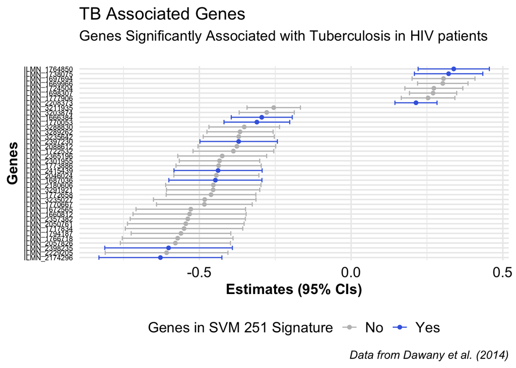

```r
dat_forest_plot <- dat_estimates |>
  filter(significant == "Yes")

forest_plot <- ggplot(data = dat_forest_plot,
                      aes(x=estimate,
                          y=fct_reorder(gene, estimate),
                          xmin = conf.low,
                          xmax = conf.high,
                          color = signature_251)) +
  geom_errorbarh() +
  geom_point() +
  scale_color_manual(values = c("Yes" = "royalblue",
                                "No" = "gray")) +
  labs(x = "Estimates (95% CIs)",
       y = "",
       title = "Genes Associated with Tuberculosis in HIV patients") +
  theme_minimal(base_size = 14) +
  labs(x = "Estimates (95% CIs)",
       y = "Genes",
       title = "TB Associated Genes",
       subtitle = str_c("Genes Significantly Associated with Tuberculosis in HIV patients",
                        "\n",
                        ""),
       color = "Genes in SVM 251 Signature",
       caption = "Data from Dawany et al. (2014)") +
  theme(axis.text.x = element_text(color = "black",
                                   size = 14),
        axis.text.y = element_text(color = "black",
                                   size = 7),
        axis.title = element_text(face="bold"),
        plot.caption = element_text(face = "italic"),
        legend.text = element_text(size = 14),
        legend.position = "bottom")

ggsave("../results/forest_plot.png", plot = forest_plot)
show(forest_plot)
```

We see that most genes are down-regulated.

### Volcano Plot

A volcano plot is generated to show significance of the genes as a function of the gene expression estimates.

```r
dat_volcano_plot <- dat_estimates |>
  mutate(gene_labels = case_when(
    significant == "Yes" & signature_251 == "Yes" ~ gene_symbol,
                                 TRUE ~ ""))

volcano_plot <- ggplot(data = dat_volcano_plot,
                       aes(x = estimate,
                           y = -log10(p.value),
                           color = significant,
                           label = gene_labels
                           )) +
  geom_point(aes(alpha = 0.7)) +
  geom_point(data=dat_volcano_plot |>
               filter(signature_251 == "Yes"),
             pch=21,
             size=2.5,
             colour="black") +
  scale_color_manual(values = c("Yes" = "royalblue",
                                "No" = "gray")) +
  theme_minimal(base_size = 16) +
  labs(x = "Estimates",
       y = "-log10(p)",
       title = "Genes Associated with Tuberculosis",
       subtitle = str_c("Genes highlighted in blue were significant after multiple",
                        "\n",
                        "testing correction."),
       caption = "Data from Dawany et al. (2014)") +
  theme(legend.position = "None",
        axis.text.x = element_text(color = "black",
                                   size = 14),
        axis.text.y = element_text(color = "black",
                                   size = 14),
        axis.title = element_text(face="bold"),
        plot.caption = element_text(face = "italic"),
        legend.text = element_text(size = 14)) +
  geom_text_repel(size = 2,
                  max.overlaps = 30)


ggsave("../results/volcano_plot.png",plot = volcano_plot)
```

```r
file.rename(from = "00_all.html",
            to = "../results/00_all.html")
```

```
[1] TRUE
```